# Workflow 3 - Image Pre Processing Stage

## Aim

- To Identify and Remove Images that will cause problems for the CNN Classification Task
- These might be Blank Images, Occluded Images or Invalid Address Images
- Uses Pytorch Library
- Places365 Pretrained CNN Model Selector

## Method

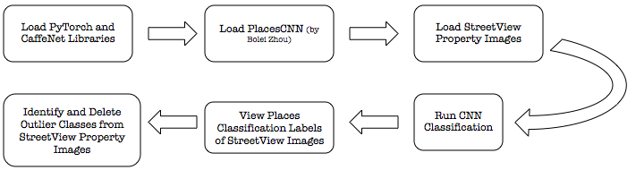

## Set Up

```python
#PyTorch Libraries
import torch
from torch.autograd import Variable as V
import torchvision.models as models
from torchvision import transforms as trn
from torch.nn import functional as F
#Essentials
import os
import numpy as np
#import pandas as pd
from PIL import Image
```

#Check We are in the Python 2 Pytorch Environment #!conda list

```python
import sys
print(sys.executable)
```

```
/Users/anthonysutton/ml7/env/bin/python2
```

```python
#Notebook Rendering Libraries
from IPython.display import Markdown, display
from IPython.display import Image as Img
```

```python
#Utils
import sys
#!conda install --yes --prefix {sys.prefix} numpy
#!jupyter notebook --prefix {sys.prefix} --version
```

```python
# Widgets
from __future__ import print_function
from ipywidgets import interact, interactive, fixed, interact_manual, Layout, Button
import ipywidgets as widgets
```

## Processing Stage 1 - Using Pre Trained Places365 CNN to Remove Outlier Images

- PlacesCNN convolutional neural networks (CNNs) trained on Places365. Places365 is an Image DataSet of 1.8 million images from 365 scene categories(e.g. Phone Booth, Theatre or Field).
- We use this Pytorch implemeted CNN to remove Google StreetView(SV) images that are occluded or that are not specificaly of a Building Type.
- http://places2.csail.mit.edu

```python
#CNN Model Arch Selector Widget

arch_toggle = widgets.ToggleButtons(
    options=['resnet18', 'alexnet', 'resnet50', 'densenet161'],
    description='<b>Select:</b>',
    disabled=False,
    button_style='', # 'success', 'info', 'warning', 'danger' or ''
    tooltips=['resnet18', 'alexnet', 'resnet50', 'densenet161'],
#     icons=['check'] * 3
)
display(arch_toggle)
```

```python
arch = arch_toggle.value
print(arch)
```

```
resnet18
```

```python
    model_file = '%s_places365.pth.tar' % arch
    print(model_file)
```

```
resnet18_places365.pth.tar
```

```python
# PlacesCNN for scene classification
#
# by Bolei Zhou
# last modified by Bolei Zhou, Dec.27, 2017 with latest pytorch and torchvision
#(upgrade your torchvision please if there is trn.Resize error)

# last modified by Anthony Sutton August 2017

def run_places(image):

    # load the pre-trained weights
    model_file = '%s_places365.pth.tar' % arch
    #print(model)
    if not os.access(model_file, os.W_OK):
        weight_url = 'http://places2.csail.mit.edu/models_places365/' + model_file
        os.system('wget ' + weight_url)

    model = models.__dict__[arch](num_classes=365)
    checkpoint = torch.load(model_file, map_location=lambda storage, loc: storage)
    state_dict = {str.replace(k,'module.',''): v for k,v in checkpoint['state_dict'].items()}
    model.load_state_dict(state_dict)
    model.eval()


    # load the image transformer
    centre_crop = trn.Compose([
            trn.Resize((256,256)),
            trn.CenterCrop(224),
            trn.ToTensor(),
            trn.Normalize([0.485, 0.456, 0.406], [0.229, 0.224, 0.225])
    ])

    # load the class label
    file_name = 'categories_places365.txt'
    if not os.access(file_name, os.W_OK):
        synset_url = 'https://raw.githubusercontent.com/csailvision/places365/master/categories_places365.txt'
        os.system('wget ' + synset_url)
    classes = list()
    with open(file_name) as class_file:
        for line in class_file:
            classes.append(line.strip().split(' ')[0][3:])
    classes = tuple(classes)

    # load the test image
    img_name = '12.jpg'
    if not os.access(img_name, os.W_OK):
        img_url = 'http://places.csail.mit.edu/demo/' + img_name
        os.system('wget ' + img_url)

    #img_name = '/Users/anthonysutton/ml2/_STREETVIEW_EXPLORER/LDD_Complete/Batch2/col_id_29335.jpg'
    img_name = image
    img = Image.open(img_name)
    input_img = V(centre_crop(img).unsqueeze(0))

    # forward pass
    logit = model.forward(input_img)
    #h_x = F.softmax(logit, 1).data.squeeze()
    h_x = F.softmax(logit).data.squeeze()
    probs, idx = h_x.sort(0, True)

    print('{} prediction on {}'.format(arch,img_name))
    # output the prediction
    #just extract class label - AS 03/08/2018
    for i in range(0, 1):

        #just extract class label - AS 03/08/2018
        category = classes[idx[i]]
        #print('{:.3f} -> {}'.format(probs[i], classes[idx[i]]))

    #return probs, idx, category
    return probs, category

#test, test2 = run_places()
```

### Test Run Places365 CNN Function

```python
#test_image = '/Users/anthonysutton/ml2/_STREETVIEW_EXPLORER/LABELRUN_STORE/JULY10_RUN/col_id_42.jpg'
test_image = '/Users/anthonysutton/ml2/_FINAL_SCRIPT_LIBRARY/LABELS/LABEL_RUN_17/FLAT/col_id_5757.jpg'

prob, category = run_places(test_image)
category
```

```
resnet18 prediction on /Users/anthonysutton/ml2/_FINAL_SCRIPT_LIBRARY/LABELS/LABEL_RUN_17/FLAT/col_id_5757.jpg
```

```
'hotel/outdoor'
```

[figure not shown]

```python
Img(test_image)
```

## Examining Places 365 Classifications in Image Folders

### View the Places365 Labels

```python
# %load https://raw.githubusercontent.com/csailvision/places365/master/categories_places365.txt
data = np.genfromtxt('Workflow_Images/Places365CNNLabels_2.csv', dtype='str')
#print(data)
places_select = widgets.SelectMultiple(
    options=data,
    #value='OSX',
    rows=15,
    description='Labels:',
    disabled=False
)

display(places_select)
```

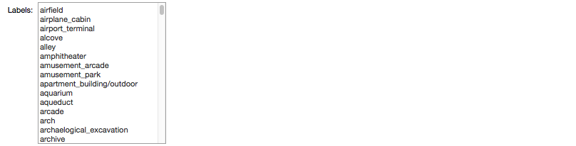

```python
places = places_select.value
print(places)
```

```
()
```

### Browse and Select Image Folder to Process

```python
LabelNameFolder = LabelNameFolder_Select.value
print(LabelNameFolder)
```

```python
LabelNameFolder = "/Users/anthonysutton/ml2/_FINAL_SCRIPT_LIBRARY/LABELS/LABEL_RUN_2._2_TEST"
```

```python
# View Classes
### Loop Through CSV
import os

#REG EX for Pattern Searching
#import re
#pattern = re.compile(r'^house$')
#pattern2 = re.compile(r'^house$')
#matches = [x for x in yourlist if pattern.match(x)]

# The StreetView Images of LDD Sites were downloaded into 2 Files, SV_RUN1 and SV_RUN2
#source1 = os.listdir(LabelNameFolder + '/' + 'SV_RUN1')
source1 = os.listdir(LabelNameFolder)
#source2 = os.listdir(LabelNameFolder + '/' + 'SV_RUN2')

#Check what Image Files are saved in this folder:
#print(source1)
#print(source2)

# Count Number of Images in Folder
#DIR = LabelNameFolder + '/' + 'SV_RUN1'
#print(len([name for name in os.listdir(DIR) if os.path.isfile(os.path.join(DIR, name))]))
#DIR = LabelNameFolder + '/' + 'SV_RUN2'
#print(len([name for name in os.listdir(DIR) if os.path.isfile(os.path.join(DIR, name))]))

print(len([name for name in os.listdir(LabelNameFolder) if os.path.isfile(os.path.join(LabelNameFolder, name))]))
```

```
1
```

### View Places365 Classifications of Images in the selected Image Folder

```python
#    image = LabelNameFolder + '/' +  filename
#    #image = LabelNameFolder + '/' + 'SV_RUN1/' +  filename
#    #print(image)
#    #if filename <> '.DS_Store':
#    probs, idx, category = run_places(image)
#    #category = 'cata'
#    left_trim = filename[7:]
#    right_trim = left_trim[:-4]
#    temp_id = right_trim
#    print(filename + '<b>' + tempid + '</b>' + ' delete?')
#    #display(Markdown('IMAGE ID = ' + filename))
#    display(Markdown('Places Category = ' + category))


rootdir = LabelNameFolder

images = []
count = 0
for subdir, dirs, files in os.walk(rootdir):
    for file in files:
        count = count + 1
        print(count)
        if file != '.DS_Store':
                print(os.path.join(subdir, file))
                image = os.path.join(subdir, file)
                #probs, idx, category = run_places(image)
                prob, category = run_places(image)
                left_trim = file[7:]
                right_trim = left_trim[:-4]
                temp_id = right_trim
                print(temp_id, category)
                # leave out prob, causing formatting error
                np_input = (temp_id, category, image)
                images.append(np_input)

print("Done")

a = np.asarray(images)
np.savetxt("ldd_image_mungeSun_.csv", a, fmt='%5s',delimiter=",", header = "TempID, Category, Image, Prob", comments = "")
```

[output not shown]

**Limit Output** (NB Extension)

### Select and View an Image to Decide whether to Delete the Class

```python
Image_Tag = raw_input()
```

```
/Users/anthonysutton/ml2/_FINAL_SCRIPT_LIBRARY/LABELS/LABEL_RUN_17/FLAT/col_id_5757.jpg
```

[figure not shown]

```python
Img(Image_Tag)
```

## Method 1 - Delete Non Matching Class Labels

#### Select Places365 Labels

```python
places_select = widgets.SelectMultiple(
    options=data,
    rows=15,
    description='Labels:',
    disabled=False
)

display(places_select)
```

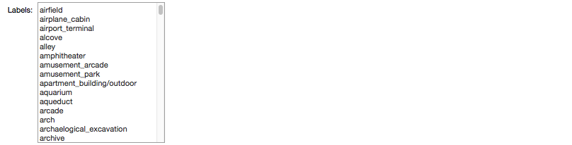

```python
places = places_select.value
print(places)
```

```
('inn/outdoor', 'residential_neighborhood')
```

#### Delete All Non Matching Categories

```python
import os

source = os.listdir( LabelRunFolder + '/' + LabelNameFolder)
#print(source)

for filename in source:

    image = LabelNameFolder + '/' +  filename
    #print(image)

    if filename <> '.DS_Store':
        probs, idx, category = run_places(image)
        flag = True
        for a in places:
            #print()
            print('Selected Class =' + a)
            print('Image Class =' + category)
            if (a in category):
                flag = False
                #display(Markdown('Category Match...Exit'))
                print('We have a Category Match...Keep Image')
                break
        if (flag is True):
            #print()
            #display(Markdown('No Category Match...Delete'))
            print('No Category Match...Delete Image')
            #os.remove(image)
        print('--------------------------')
```

[figure not shown]

## Method 2 - Delete All Images of Selected Class Type

### Select Places365 Labels

```python
places_select = widgets.Select(
    options=data,
    #value='OSX',
    rows=15,
    description='Labels:',
    disabled=False
)

display(places_select)
```

- The Places365 Label, "Snowfield", will identify Blank Google StreetView Images

```python
places = places_select.value
print(places)
```

```
snowfield
```

### Delete Matching Labels

```python
import os
rootdir = '/Users/anthonysutton/ml2/_FINAL_SCRIPT_LIBRARY/LABELS/LABEL_RUN_55/train'

for subdir, dirs, files in os.walk(rootdir):
    for file in files:
        print(os.path.join(subdir, file))
```

```
/Users/anthonysutton/ml2/_FINAL_SCRIPT_LIBRARY/LABELS/LABEL_RUN_55/train/.DS_Store
/Users/anthonysutton/ml2/_FINAL_SCRIPT_LIBRARY/LABELS/LABEL_RUN_55/train/df_cat_commercial_office_major_train/.DS_Store
/Users/anthonysutton/ml2/_FINAL_SCRIPT_LIBRARY/LABELS/LABEL_RUN_55/train/df_cat_commercial_office_major_train/SV_RUN1/col_id_10358.jpg
/Users/anthonysutton/ml2/_FINAL_SCRIPT_LIBRARY/LABELS/LABEL_RUN_55/train/df_cat_commercial_office_major_train/SV_RUN1/col_id_10628.jpg
/Users/anthonysutton/ml2/_FINAL_SCRIPT_LIBRARY/LABELS/LABEL_RUN_55/train/df_cat_commercial_office_major_train/SV_RUN1/col_id_10706.jpg
/Users/anthonysutton/ml2/_FINAL_SCRIPT_LIBRARY/LABELS/LABEL_RUN_55/train/df_cat_commercial_office_major_train/SV_RUN1/col_id_10990.jpg
/Users/anthonysutton/ml2/_FINAL_SCRIPT_LIBRARY/LABELS/LABEL_RUN_55/train/df_cat_commercial_office_major_train/SV_RUN1/col_id_11025.jpg
/Users/anthonysutton/ml2/_FINAL_SCRIPT_LIBRARY/LABELS/LABEL_RUN_55/train/df_cat_commercial_office_major_train/SV_RUN1/col_
```

**Limit Output** (NB Extension)

```python
#rootdir = '/Users/anthonysutton/ml2/_FINAL_SCRIPT_LIBRARY/LABELS/LABEL_RUN_50'
rootdir = '/Users/anthonysutton/ml2/_FINAL_SCRIPT_LIBRARY/LABELS/LABEL_RUN_56'

images = []
count = 0
for subdir, dirs, files in os.walk(rootdir):
    for file in files:
        count = count + 1
        print(count)
        if file <> '.DS_Store':
            if count < 100000:
                print(os.path.join(subdir, file))
                image = os.path.join(subdir, file)

                probs, idx, category = run_places(image)
                print( category)
                if (category in 'snowfield'):
                    images.append(image)
                    os.remove(image)
                    print("!!! NOT deleting " + image)

print("Done")

a = np.asarray(images)
np.savetxt("london_wide_56.csv", a, fmt='%5s',delimiter=",")
```

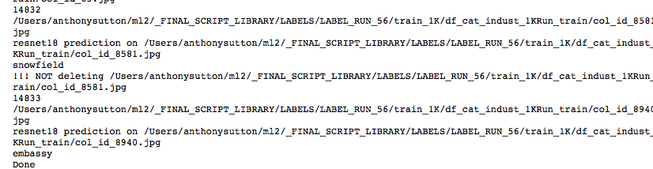

```python
np.savetxt("london_wide_56_2.csv", a, fmt='%5s',delimiter=",")
```

```python
print(a)
```

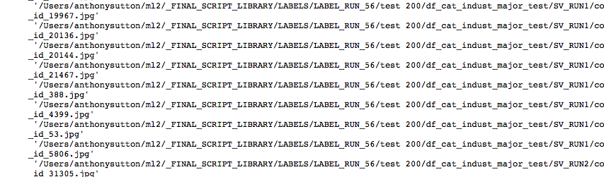

## Last Minute Bucket Cleaning for the 2018 Study Workflow

### Bulk Folder Deletion

```python
import os
import csv
#import pandas as pd
count = 0
with open('london_boros.csv') as csvfile:

    reader = csv.reader(csvfile)

    for row in reader:
        count = count + 1
        image = str(row[0])
        print(count)
        print("deleting " + image)
        os.remove(image)
```

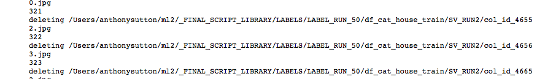

### Clean Up Missed "No Image Available"

```python
#London Complete Clean
import os
import csv
#import pandas as pd
count = 0
with open('ldd_snow.csv') as csvfile:

    reader = csv.reader(csvfile)

    for row in reader:
        count = count + 1
        image = str(row[0])
        print(count)
        print(image)
```

```
1
/Users/banana/Documents/ML4/LDD_Complete/col_id_15982.jpg
2
/Users/banana/Documents/ML4/LDD_Complete/col_id_5697.jpg
3
/Users/banana/Documents/ML4/LDD_Complete/col_id_1368.jpg
4
/Users/banana/Documents/ML4/LDD_Complete/col_id_8358.jpg
5
/Users/banana/Documents/ML4/LDD_Complete/col_id_12960.jpg
6
/Users/banana/Documents/ML4/LDD_Complete/col_id_20044.jpg
7
/Users/banana/Documents/ML4/LDD_Complete/col_id_3231.jpg
8
/Users/banana/Documents/ML4/LDD_Complete/col_id_7057.jpg
9
/Users/banana/Documents/ML4/LDD_Complete/col_id_3972.jpg
10
/Users/banana/Documents/ML4/LDD_Complete/col_id_12579.jpg
11
/Users/banana/Documents/ML4/LDD_Complete/col_id_12551.jpg
12
/Users/banana/Documents/ML4/LDD_Complete/col_id_20285.jpg
13
/Users/banana/Documents/ML4/LDD_Complete/col_id_20291.jpg
14
/Users/banana/Documents/ML4/LDD_Complete/col_id_16723.jpg
15
/Users/banana/Documents/ML4/LDD_Complete/col_id_3769.jpg
16
/Users/banana/Documents/ML4/LDD_Complete/col_id_228.jpg
17
/Users/banana/Documents/ML4/LDD_Complet
```

**Limiting Output to reduce size of Notebook** (NB Extension)

```python
#London Complete Clean
import os
import csv
#import pandas as pd
count = 0
with open('ldd_snow.csv') as csvfile:

    reader = csv.reader(csvfile)

    for row in reader:
        count = count + 1
        image = str(row[0])
        print(count)
        #print("deleting " + image)
        #> 29192
        image_str = os.path.basename(image)
        y = image_str.replace('col_id_','')
        z = y.replace('.jpg','')
        print(z)
        if int(z) <= 29192:
            image_del = '/Users/anthonysutton/ml2/_STREETVIEW_EXPLORER/LDD_Complete/' + os.path.basename(image)
            print("deleting " + image_del)
        elif int(z) > 29192:
            image_del = '/Users/anthonysutton/ml2/_STREETVIEW_EXPLORER/LDD_Complete/batch2/' + os.path.basename(image)
            print("deleting " + image_del)
        #print('del')
        os.remove(image_del)
print('done')
```

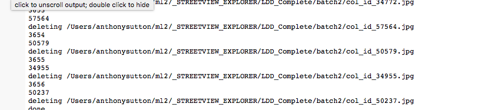

### One Off Category Runs during Label Set Making Stages

#### PROPERTY TYPE = HOUSE

```python
### Loop Through CSV
import os

#REG EX for Pattern Searching
#import re
#pattern = re.compile(r'^house$')
#pattern2 = re.compile(r'^house$')
#matches = [x for x in yourlist if pattern.match(x)]

source = os.listdir('/Users/anthonysutton/ml2/_FINAL_SCRIPT_LIBRARY/LABEL_RUN_2/HOUSE_TERRACE/')
#source = os.listdir('/Users/anthonysutton/ml2/_FINAL_SCRIPT_LIBRARY/LABEL_RUN_1/HOUSE/SV_RUN2')

for filename in source:

    #print('/Users/anthonysutton/ml2/_FINAL_SCRIPT_LIBRARY/LABEL_RUN_1/HOUSE/SV_RUN1' + filename)
    image = '/Users/anthonysutton/ml2/_FINAL_SCRIPT_LIBRARY/LABEL_RUN_2/HOUSE_TERRACE/' + filename
    #image = '/Users/anthonysutton/ml2/_FINAL_SCRIPT_LIBRARY/LABEL_RUN_1/HOUSE/SV_RUN2/' + filename

    if filename <> '.DS_Store':
        test, test2, category = run_places(image)
        if (("house" not in category) & ("residential_neighborhood" not in category) & ("drive" not in category)
            & ("manufactured_home" not in category) & ("outdoor" not in category) & ("drive" not in category)
            & ("cottage" not in category)):

            left_trim = filename[7:]
            right_trim = left_trim[:-4]
            temp_id = right_trim
            print(filename + ' ' + category +' delete?')
            os.remove(image)
            print(filename + 'deleted')

            #try:
                #os.remove(filename)
                #print(filename + 'deleted')
            #except OSError:
                #pass


        #Get List of Accepted Places Categories
        #residential_neighborhood, %house%
        #Strip Out FileName for temp ID
        #Open LDD_AB File, add Label Class to the LDD-Street View Cadastre Model
        #Delete Outlier Image File

print("Done")
```

```python
### Remove Outliers from Label Bin. Adding this away from original iterator to avoid any
## IO errors when deleting files.
## TO DO: Why are there OUTLIERS?
```

#### PROPERTY TYPE = FLAT

```python
### Loop Through CSV
import os

#REG EX for Pattern Searching
#import re
#pattern = re.compile(r'^house$')
#pattern2 = re.compile(r'^house$')
#matches = [x for x in yourlist if pattern.match(x)]

#source = os.listdir('/Users/anthonysutton/ml2/_FINAL_SCRIPT_LIBRARY/LABEL_RUN_2/FLAT_MAJOR')
source = os.listdir('/Users/anthonysutton/ml2/_FINAL_SCRIPT_LIBRARY/LABEL_RUN_2/FLAT_MINOR')


for filename in source:
    #print('/Users/anthonysutton/ml2/_FINAL_SCRIPT_LIBRARY/LABEL_RUN_1/FLAT/SV_RUN1' + filename)
    #image = '/Users/anthonysutton/ml2/_FINAL_SCRIPT_LIBRARY/LABEL_RUN_2/FLAT_MAJOR/' + filename
    image = '/Users/anthonysutton/ml2/_FINAL_SCRIPT_LIBRARY/LABEL_RUN_2/FLAT_MINOR/' + filename

    if filename <> '.DS_Store':
        test, test2, category = run_places(image)
        if (("apartment" not in category) & ("residential_neighborhood" not in category) & ("building_facade" not in category)
            & ("manufactured_home" not in category) & ("outdoor" not in category) & ("motel" not in category)
         & ("hotel" not in category) & ("hospital" not in category) & ("outdoor" not in category)):

            left_trim = filename[7:]
            right_trim = left_trim[:-4]
            temp_id = right_trim
            print(image + ' ' + category +' delete?')
            os.remove(image)
            print(filename + 'deleted')

            #try:
                #os.remove(filename)
                #print(filename + 'deleted')
            #except OSError:
                #pass


    #Get List of Accepted Places Categories
    #residential_neighborhood, %house%
    #Strip Out FileName for temp ID
    #Open LDD_AB File, add Label Class to the LDD-Street View Cadastre Model
    #Delete Outlier Image File

print("Done")
```

#### PROPERTY TYPE = COMMERCIAL/INDUSTRIAL

```python
### Loop Through CSV
import os

#REG EX for Pattern Searching
#import re
#pattern = re.compile(r'^house$')
#pattern2 = re.compile(r'^house$')
#matches = [x for x in yourlist if pattern.match(x)]

source = os.listdir('/Users/anthonysutton/ml2/_FINAL_SCRIPT_LIBRARY/LABEL_RUN_1/COMMERCIAL/SV_RUN2')
#source = os.listdir('/Users/anthonysutton/ml2/_FINAL_SCRIPT_LIBRARY/LABEL_RUN_1/FLAT/SV_RUN2')

for filename in source:
    #print('/Users/anthonysutton/ml2/_FINAL_SCRIPT_LIBRARY/LABEL_RUN_1/FLAT/SV_RUN1' + filename)
    image = '/Users/anthonysutton/ml2/_FINAL_SCRIPT_LIBRARY/LABEL_RUN_1/COMMERCIAL/SV_RUN2/' + filename
    #image = '/Users/anthonysutton/ml2/_FINAL_SCRIPT_LIBRARY/LABEL_RUN_1/FLAT/SV_RUN2/' + filename

    test, test2, category = run_places(image)
    if (("industrial_area" not in category) & ("downtown" not in category) & ("building_facade" not in category)
     & ("downtown" not in category) & ("building_facade" not in category) & ("shopfront" not in category)
      & ("airport_terminal" not in category) & ("general_store" not in category) & ("motel" not in category)
         & ("hotel" not in category) & ("building_facade" not in category) & ("pharmacy" not in category)
              & ("downtown" not in category) & ("building_facade" not in category) & ("shopfront" not in category)
                     & ("outdoor" not in category)):

        left_trim = filename[7:]
        right_trim = left_trim[:-4]
        temp_id = right_trim
        print(image + ' ' + category +' delete?')
        os.remove(image)
        print(filename + 'deleted')

    #try:
        #os.remove(filename)
        #print(filename + 'deleted')
    #except OSError:
        #pass


    #Get List of Accepted Places Categories
    #residential_neighborhood, %house%
    #Strip Out FileName for temp ID
    #Open LDD_AB File, add Label Class to the LDD-Street View Cadastre Model
    #Delete Outlier Image File

print("Done")
```

#### PROPERTY TYPE = INDUSTRIAL

```python
### Loop Through CSV
import os

#REG EX for Pattern Searching
#import re
#pattern = re.compile(r'^house$')
#pattern2 = re.compile(r'^house$')
#matches = [x for x in yourlist if pattern.match(x)]

source = os.listdir('/Users/anthonysutton/ml2/_FINAL_SCRIPT_LIBRARY/LABEL_RUN_1/INDUSTRIAL/SV_RUN2')
#source = os.listdir('/Users/anthonysutton/ml2/_FINAL_SCRIPT_LIBRARY/LABEL_RUN_1/FLAT/SV_RUN2')

count = 1
for filename in source:
    #print('/Users/anthonysutton/ml2/_FINAL_SCRIPT_LIBRARY/LABEL_RUN_1/FLAT/SV_RUN1' + filename)
    image = '/Users/anthonysutton/ml2/_FINAL_SCRIPT_LIBRARY/LABEL_RUN_1/INDUSTRIAL/SV_RUN2/' + filename
    #image = '/Users/anthonysutton/ml2/_FINAL_SCRIPT_LIBRARY/LABEL_RUN_1/FLAT/SV_RUN2/' + filename

    test, test2, category = run_places(image)
    if (("industrial_area" not in category) & ("loading_dock" not in category)
    & ("garage" not in category)
     & ("hangar" not in category) & ("racecourse" not in category)
        #& ("barndoor" not in category)   & ("storage_room" not in category)

    # & ("general_store" not in category) & ("motel" not in category)
    #     & ("hotel" not in category) & ("building_facade" not in category) & ("pharmacy" not in category)
    #          & ("downtown" not in category) & ("building_facade" not in category) & ("shopfront" not in category)
    #                 & ("outdoor" not in category)
    ):

        left_trim = filename[7:]
        right_trim = left_trim[:-4]
        temp_id = right_trim
        print(image + ' ' + category +' delete?')
        os.remove(image)
        print(filename + 'deleted')
    count = count + 1
    print(count)

    #try:
        #os.remove(filename)
        #print(filename + 'deleted')
    #except OSError:
        #pass


    #Get List of Accepted Places Categories
    #residential_neighborhood, %house%
    #Strip Out FileName for temp ID
    #Open LDD_AB File, add Label Class to the LDD-Street View Cadastre Model
    #Delete Outlier Image File

print("Done")
```

```python
### PROPERTY TYPE = OFFICE
```

```python
### Loop Through CSV
import os

#REG EX for Pattern Searching
#import re
#pattern = re.compile(r'^house$')
#pattern2 = re.compile(r'^house$')
#matches = [x for x in yourlist if pattern.match(x)]

source = os.listdir('/Users/anthonysutton/ml2/_FINAL_SCRIPT_LIBRARY/LAB RUNS ODD BODS/OFFICE')
#source = os.listdir('/Users/anthonysutton/ml2/_FINAL_SCRIPT_LIBRARY/LABEL_RUN_1/FLAT/SV_RUN2')

count = 1
for filename in source:
    #print('/Users/anthonysutton/ml2/_FINAL_SCRIPT_LIBRARY/LABEL_RUN_1/FLAT/SV_RUN1' + filename)
    image = '/Users/anthonysutton/ml2/_FINAL_SCRIPT_LIBRARY/LAB RUNS ODD BODS/OFFICE/' + filename
    #image = '/Users/anthonysutton/ml2/_FINAL_SCRIPT_LIBRARY/LABEL_RUN_1/FLAT/SV_RUN2/' + filename

    if filename <> '.DS_Store':
        test, test2, category = run_places(image)
        if (("downtown" not in category) & ("plaza" not in category)
           & ("motel" not in category)
             & ("hotel" not in category) & ("hospital" not in category)
                & ("office_building" not in category)   & ("storage_room" not in category)

        # & ("general_store" not in category) & ("motel" not in category)
        #     & ("hotel" not in category) & ("building_facade" not in category) & ("pharmacy" not in category)
        #          & ("downtown" not in category) & ("building_facade" not in category) & ("shopfront" not in category)
        #                 & ("outdoor" not in category)
        ):

            left_trim = filename[7:]
            right_trim = left_trim[:-4]
            temp_id = right_trim
            print(image + ' ' + category +' delete?')
            #os.remove(image)
            print(filename + 'deleted')
        count = count + 1
        print(count)

        #try:
            #os.remove(filename)
            #print(filename + 'deleted')
        #except OSError:
            #pass


    #Get List of Accepted Places Categories
    #residential_neighborhood, %house%
    #Strip Out FileName for temp ID
    #Open LDD_AB File, add Label Class to the LDD-Street View Cadastre Model
    #Delete Outlier Image File

print("Done")
```

#### PROPERTY TYPE = RETAIL

```python
### Loop Through CSV
import os

#REG EX for Pattern Searching
#import re
#pattern = re.compile(r'^house$')
#pattern2 = re.compile(r'^house$')
#matches = [x for x in yourlist if pattern.match(x)]

source = os.listdir('/Users/anthonysutton/ml2/_FINAL_SCRIPT_LIBRARY/LABEL_RUN_1/COMMERCIAL/SV_RUN2')
#source = os.listdir('/Users/anthonysutton/ml2/_FINAL_SCRIPT_LIBRARY/LABEL_RUN_1/FLAT/SV_RUN2')

count = 1
for filename in source:
    #print('/Users/anthonysutton/ml2/_FINAL_SCRIPT_LIBRARY/LABEL_RUN_1/FLAT/SV_RUN1' + filename)
    image = '/Users/anthonysutton/ml2/_FINAL_SCRIPT_LIBRARY/LABEL_RUN_1/INDUSTRIAL/SV_RUN2/' + filename
    #image = '/Users/anthonysutton/ml2/_FINAL_SCRIPT_LIBRARY/LABEL_RUN_1/FLAT/SV_RUN2/' + filename

    test, test2, category = run_places(image)
    if (("industrial_area" not in category) & ("loading_dock" not in category)
    & ("garage" not in category)
     & ("hangar" not in category) & ("racecourse" not in category)
        #& ("barndoor" not in category)   & ("storage_room" not in category)

    # & ("general_store" not in category) & ("motel" not in category)
    #     & ("hotel" not in category) & ("building_facade" not in category) & ("pharmacy" not in category)
    #          & ("downtown" not in category) & ("building_facade" not in category) & ("shopfront" not in category)
    #                 & ("outdoor" not in category)
    ):

        left_trim = filename[7:]
        right_trim = left_trim[:-4]
        temp_id = right_trim
        print(image + ' ' + category +' delete?')
        #os.remove(image)
        print(filename + 'deleted')
    count = count + 1
    print(count)

    #try:
        #os.remove(filename)
        #print(filename + 'deleted')
    #except OSError:
        #pass


    #Get List of Accepted Places Categories
    #residential_neighborhood, %house%
    #Strip Out FileName for temp ID
    #Open LDD_AB File, add Label Class to the LDD-Street View Cadastre Model
    #Delete Outlier Image File

print("Done")
```

```python
## To Do: Programmatically Enable the Above
```

## Processing Stage 2 - Using Google StreetView Meta Info API to remove Outlier Images

- Additional Processing step to Remove Problem Images from the Image Label Run Folder
- Should be carried out on Script 2 but download attempt problems (i.e. July Price Hike > 500%, Power Failure) required several batch bulk attempts (and piecing together) rather than 1 single download

### Load and Inspect Meta Results File

```python
#df.to_csv('/Users/anthonysutton/ml2/_ACORN_EXPLORER/final_acorn_label_upload9_results2.csv')

#Load CSV
#Includes stripping for NULLs
df_results = pd.read_csv('/Users/anthonysutton/ml2/_ACORN_EXPLORER/final_acorn_label_upload9_results.csv',  sep=',',
                           error_bad_lines=False, index_col=False,  na_values=['.'], encoding="ISO-8859-1")

#df_results = pd.read_csv('ab_london_goo_sv_meta_1.csv',  sep=',',
#                           error_bad_lines=False, index_col=False,  na_values=['.'], encoding='utf-8')
```

```python
df_results.head()
```

```python
### Only Load "Status == ZERO RESULTS" Images into Locations Array
```

```python
df_json_parse_valid = df_json_parse[df_json_parse['status'] == 'OK']

#We can also use DATE AND RADIUS Google API Variables. E.g. Only use images from specific date ranges, or photos
#taken from specific distance,to avoid outliers. The efault is 50m

df_json_parse_valid.shape
df_json_parse_valid.head(1)
```

```python
### Sweep though Selected Image Buckets and Remove Blank Images
```

### Create and Load Up X&Y Location Array

```python
import csv
import codecs


# Open the file, grab the lat and lon values as floats,
# and store in the "locations" array.
#print("test")

locations = []
responses = []

#Old London Joined on Acorn Categories
with codecs.open('ab_london_goo_sv_meta_2.csv',
          encoding = "ISO-8859-1") as csvfile:
#/Users/anthonysutton/ml2/_LDD_EXPLORER/JULY13_RUN/ldd_totalafford_plus10.csv
#/Users/anthonysutton/ml2/_LDD_EXPLORER/JULY13_RUN/ldd_totalafford0_resiplus10_notjoined.csv!!!
#/Users/anthonysutton/ml2/_LDD_EXPLORER/JULY13_RUN/ldd_totalafford0_resiplus10.csv
#/Users/anthonysutton/ml2/_LDD_EXPLORER/JULY13_RUN/ldd_totalresi_less10.csv
#/Users/anthonysutton/ml2/_LDD_EXPLORER/JULY13_RUN/ldd_totalresi_plus10.csv

    #with open('/Users/anthonysutton/ml2/_DATA_LABELS/LDD_STORE/LDD MODEL/LDD_Geocode_LBTH.csv', R) as csvfile:


    reader = csv.reader(csvfile)

    is_first_row = True
    for row in reader:
        # Skip the first row.
        if is_first_row:
            is_first_row = False
            continue


        #col, lat, lon = str(row[1]),  float(row[51]), float(row[52])
        col, status, lat, lon = str(row[1]), str(row[6]),  str(row[3]), str(row[4])
        if str(status) == "ZERO_RESULTS":
        #if (int(col)> 1 and int(col)< 48):
            #and "BR"in str(post)):
            #& int(col)  < 138647
            location = (col, status, lat, lon)
            #print("location="+ str(location))
            locations.append(location)


print ("Done")
#locations = locations[:-1]
```

```
Done
```

```python
locations
```

```
[('21', 'ZERO_RESULTS', 'RM9', '51.54259219'),
 ('2', 'ZERO_RESULTS', 'IG11 0DY', '51.51586365'),
 ('27', 'ZERO_RESULTS', 'RM9 4', '51.54006708')]
```

### Sweep Though Selected Image Bucket and Remove Empty SV Images

```python
import os
rootdir = '/Users/anthonysutton/ml2/_STREETVIEW_EXPLORER/LABELRUN_STORE/JULY13_RUN/LBTH_ALL'


for location in locations:
    if location[0] <= 29192
        rootdir = '/Users/anthonysutton/ml2/_STREETVIEW_EXPLORER/LDD_Complete/'

        print(location[0])

        file = location[0] + '.jpg'
        print(file)
        image = os.path.join(rootdir, file)
        print(image)
        #os.remove(image)
        #print("!!! deleting " + image)

    elif location[0] > 29192

        rootdir = '/Users/anthonysutton/ml2/_STREETVIEW_EXPLORER/LDD_Complete/batch2/'

        print(location[0])

        file = location[0] + '.jpg'
        print(file)
        image = os.path.join(rootdir, file)
        print(image)
        #os.remove(image)
        #print("!!! deleting " + image)


print("Done")
```

[output not shown]